# UNSUPERVISED LEARNING - CLUSTERING

## Ricardo López Ruiz

Date: 02/06/2021

## Abstract:

Different unsupervised learning techniques are used to identify different segments in the existing bank customers based on their spending patterns as well as past interaction with the bank.

## Techniques used in this project:

'K-means' - 'Elbow curve' - 'Silhouette Score' - 'Clusters analysis'

# Project - Credit Card Customer Segmentation

## **Context:**

You as a Data scientist forming part of the Operations team of the at AllLife bank wants to upgrade the service delivery model, to ensure that customers queries are resolved faster.

## **Background:**

AllLife Bank wants to focus on its credit card customer base in the next financial year. They have been advised by their marketing research team, that the penetration in the market can be improved. Based on this input, the Marketing team proposes to run personalised campaigns to target new customers as well as upsell to existing customers. Another insight from the market research was that the customers perceive the support services of the back poorly. Based on this, the Operations team wants to upgrade the service delivery model, to ensure that customers queries are resolved faster. Head of Marketing and Head of Delivery both decide to reach out to the Data Science team for help.

## **Objective:**

- To identify different segments in the existing customer based on their spending patterns as well as past interaction with the bank.
- To answer the key questions:
  - How many different segments of customers are there?
  - How are these segments different from each other?
  - What are your recommendations to the bank on how to better market to and service these customers?

## **Data Description:**

- Data is of various customers of a bank with their credit limit, the total number of credit cards the customer has, and different channels through which customer has contacted the bank for any queries, different channels include visiting the bank, online and through a call centre.

## Index

- Overview of the dataset
- EDA
- Kmeans
- Clusters comparison
- Business conclusion and Recomendations

## Overview of the dataset

**Let's start by importing libraries we need.**

```python
import warnings
warnings.filterwarnings("ignore")

import numpy as np
import pandas as pd
import seaborn as sns
import matplotlib.pyplot as plt
%matplotlib inline
sns.set_theme()

from scipy.spatial.distance import cdist
from scipy.stats import zscore
from sklearn.cluster import KMeans
from sklearn.preprocessing import StandardScaler
from scipy.spatial.distance import pdist
from scipy.cluster.hierarchy import dendrogram, linkage,cophenet
from sklearn.metrics import silhouette_score

#if needed: !pip install yellowbrick
from yellowbrick.cluster import KElbowVisualizer, SilhouetteVisualizer
```

```python
#Loading dataset
data=pd.read_excel("Credit Card Customer Data.xlsx")
```

**View the first rows of the dataset.**

```python
data.head()
```

|  | Sl_No | Customer Key | Avg_Credit_Limit | Total_Credit_Cards | Total_visits_bank | Total_visits_online | Total_calls_made |
| --- | --- | --- | --- | --- | --- | --- | --- |
| 0 | 1 | 87073 | 100000 | 2 | 1 | 1 | 0 |
| 1 | 2 | 38414 | 50000 | 3 | 0 | 10 | 9 |
| 2 | 3 | 17341 | 50000 | 7 | 1 | 3 | 4 |
| 3 | 4 | 40496 | 30000 | 5 | 1 | 1 | 4 |
| 4 | 5 | 47437 | 100000 | 6 | 0 | 12 | 3 |

**Check data types and number of non-null values for each column.**

```python
data.info()
```

```
<class 'pandas.core.frame.DataFrame'>
RangeIndex: 660 entries, 0 to 659
Data columns (total 7 columns):
 #   Column               Non-Null Count  Dtype
---  ------               --------------  -----
 0   Sl_No                660 non-null    int64
 1   Customer Key         660 non-null    int64
 2   Avg_Credit_Limit     660 non-null    int64
 3   Total_Credit_Cards   660 non-null    int64
 4   Total_visits_bank    660 non-null    int64
 5   Total_visits_online  660 non-null    int64
 6   Total_calls_made     660 non-null    int64
dtypes: int64(7)
memory usage: 36.2 KB
```

- We can see that there are total 7 columns and 660 rows in the dataset.
- All columns' data type is integer.
- The non-null values of each column is equal to the number of total rows in the dataset i.e. there are not null values.

```python
#Total of null data by rows
data.isna().sum()
```

```
Sl_No                  0
Customer Key           0
Avg_Credit_Limit       0
Total_Credit_Cards     0
Total_visits_bank      0
Total_visits_online    0
Total_calls_made       0
dtype: int64
```

```python
#Total of number of rows with some null data
data.isnull().any(axis=1).sum()
```

```
0
```

```python
#The first (Sl_No) and second (Customer Key) rows are numbering data of the columns, we can drop both of them
data1 = data.drop(columns=['Sl_No','Customer Key']).copy()
print(data1.info())
data1.head()
```

```
<class 'pandas.core.frame.DataFrame'>
RangeIndex: 660 entries, 0 to 659
Data columns (total 5 columns):
 #   Column               Non-Null Count  Dtype
---  ------               --------------  -----
 0   Avg_Credit_Limit     660 non-null    int64
 1   Total_Credit_Cards   660 non-null    int64
 2   Total_visits_bank    660 non-null    int64
 3   Total_visits_online  660 non-null    int64
 4   Total_calls_made     660 non-null    int64
dtypes: int64(5)
memory usage: 25.9 KB
None
```

|  | Avg_Credit_Limit | Total_Credit_Cards | Total_visits_bank | Total_visits_online | Total_calls_made |
| --- | --- | --- | --- | --- | --- |
| 0 | 100000 | 2 | 1 | 1 | 0 |
| 1 | 50000 | 3 | 0 | 10 | 9 |
| 2 | 50000 | 7 | 1 | 3 | 4 |
| 3 | 30000 | 5 | 1 | 1 | 4 |
| 4 | 100000 | 6 | 0 | 12 | 3 |

```python
# lets check duplicate observations
data1.duplicated().sum()
```

```
11
```

```python
# Remove duplicates
data1 = data1[(~data1.duplicated())].copy()
print(data1.duplicated().sum())
data1.info()
```

```
0
<class 'pandas.core.frame.DataFrame'>
Int64Index: 649 entries, 0 to 659
Data columns (total 5 columns):
 #   Column               Non-Null Count  Dtype
---  ------               --------------  -----
 0   Avg_Credit_Limit     649 non-null    int64
 1   Total_Credit_Cards   649 non-null    int64
 2   Total_visits_bank    649 non-null    int64
 3   Total_visits_online  649 non-null    int64
 4   Total_calls_made     649 non-null    int64
dtypes: int64(5)
memory usage: 30.4 KB
```

- There were 11 duplicate observations that have been removed from the data.
- We can see in this final set there are 5 columns and 649 rows of integer data in the dataset.

## EDA

### Perform an Exploratory Data Analysis on the data

- Univariate analysis - Bivariate analysis - Use appropriate visualizations to identify the patterns and insights - Any other exploratory deep dive

**Summary of the dataset**

```python
# Summary of columns
data1.describe().T
```

|  | count | mean | std | min | 25% | 50% | 75% | max |
| --- | --- | --- | --- | --- | --- | --- | --- | --- |
| Avg_Credit_Limit | 649.0 | 34878.274268 | 37813.736638 | 3000.0 | 11000.0 | 18000.0 | 49000.0 | 200000.0 |
| Total_Credit_Cards | 649.0 | 4.708783 | 2.173763 | 1.0 | 3.0 | 5.0 | 6.0 | 10.0 |
| Total_visits_bank | 649.0 | 2.397535 | 1.625148 | 0.0 | 1.0 | 2.0 | 4.0 | 5.0 |
| Total_visits_online | 649.0 | 2.624037 | 2.952888 | 0.0 | 1.0 | 2.0 | 4.0 | 15.0 |
| Total_calls_made | 649.0 | 3.590139 | 2.877911 | 0.0 | 1.0 | 3.0 | 5.0 | 10.0 |

- Mean and median value of 'Avg_Credit_Limit' is approx 35000 and 18000, respectively.
- Mean and median value for 'Total_Credit_Cards' is approx 5.
- Mean and median value for 'Total_visits_bank' is approx 2.
- Mean and median value for 'Total_visits_online' is approx 2.6 and 2, respectively.
- Mean and median value for 'Total_calls_made' is approx 3.5 and 3, respectively.
- The variables with mean and median very similar wont have much skewed distributions.
- Also the excessive max value in 'Avg_Credit_Limit' warn us about the existence of outliers.

**Number of unique values in each column**

```python
data1.nunique()
```

```
Avg_Credit_Limit       110
Total_Credit_Cards      10
Total_visits_bank        6
Total_visits_online     16
Total_calls_made        11
dtype: int64
```

**Grouping of data values**

```python
#we check number of grades in the different columns presenting with a few values
print(data1['Total_Credit_Cards'].value_counts())
print(data1['Total_visits_bank'].value_counts())
print(data1['Total_visits_online'].value_counts())
print(data1['Total_calls_made'].value_counts())
```

```
4     147
6     113
7     100
5      74
2      63
1      58
3      53
10     19
9      11
8      11
Name: Total_Credit_Cards, dtype: int64
2    156
1    112
3     99
0     97
```

[output cut: 32 more lines]

### Univariate analysis

```
5 plots
```

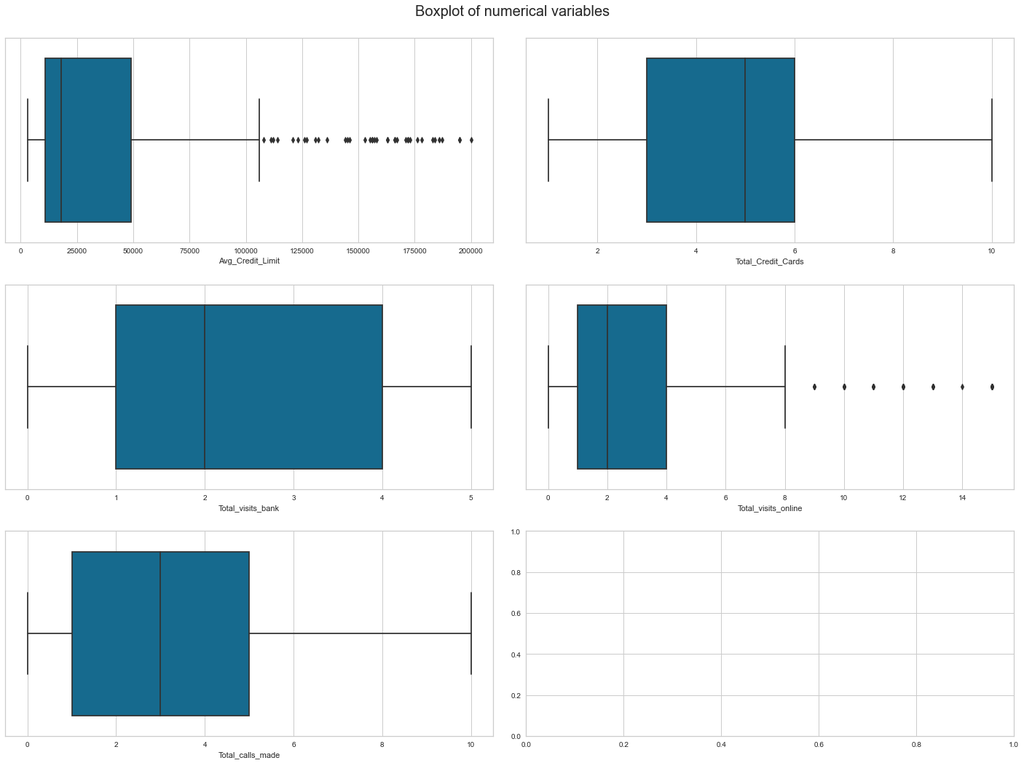

```python
# selecting numerical columns, in this case all the 5 existing columns
all_col = data1.select_dtypes(include=np.number).columns.tolist()
num_plots = len(all_col)
print(num_plots, 'plots')

fig, axes = plt.subplots(3, 2, figsize=(20, 15))
fig.suptitle('Boxplot of numerical variables', fontsize=20)
counter = 0
for ii in range(3):
    if counter < num_plots:
        sns.boxplot(ax=axes[ii][0],x=data1[all_col[counter]])
        counter = counter+1
    if counter < num_plots:
        sns.boxplot(ax=axes[ii][1],x=data1[all_col[counter]])
        counter = counter+1
    else:
        pass

fig.tight_layout(pad=2.0)
```

```
5 plots
```

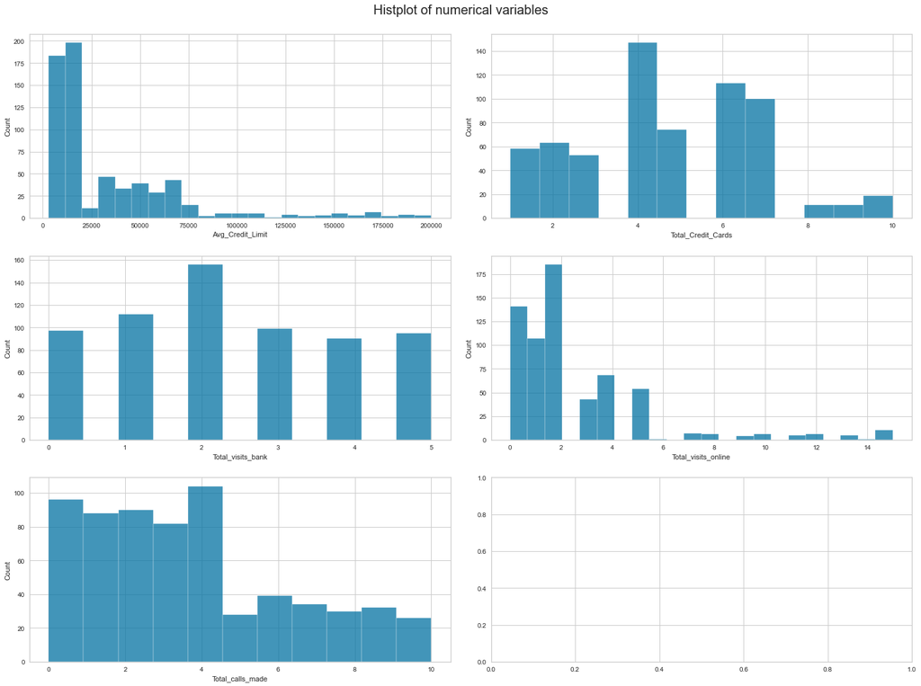

```python
# selecting numerical columns, in this case all the 5 existing columns
all_col = data1.select_dtypes(include=np.number).columns.tolist()
num_plots = len(all_col)
print(num_plots, 'plots')

fig, axes = plt.subplots(3, 2, figsize=(20, 15))
fig.suptitle('Histplot of numerical variables', fontsize=20)
counter = 0
for ii in range(3):
    if counter < num_plots:
        sns.histplot(ax=axes[ii][0],x=data1[all_col[counter]])
        counter = counter+1
    if counter < num_plots:
        sns.histplot(ax=axes[ii][1],x=data1[all_col[counter]])
        counter = counter+1
    else:
        pass

fig.tight_layout(pad=2.0)
```

```
5 plots
```

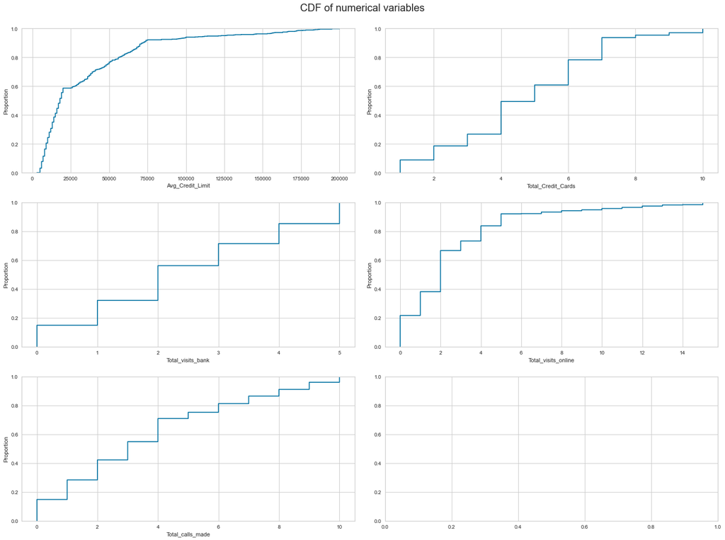

```python
# selecting numerical columns, in this case all the 5 existing columns
all_col = data1.select_dtypes(include=np.number).columns.tolist()
num_plots = len(all_col)
print(num_plots, 'plots')

fig, axes = plt.subplots(3, 2, figsize=(20, 15))
fig.suptitle('CDF of numerical variables', fontsize=20)
counter = 0
for ii in range(3):
    if counter < num_plots:
        sns.ecdfplot(ax=axes[ii][0],x=data1[all_col[counter]])
        counter = counter+1
    if counter < num_plots:
        sns.ecdfplot(ax=axes[ii][1],x=data1[all_col[counter]])
        counter = counter+1
    else:
        pass

fig.tight_layout(pad=2.0)
```

**Observations**

- 90 % of the customers have Avg_Credit_Limit less than 100000.
- 90 % of the customers have Total_visits_online less than 8.
- A capping can be done for these two variables, in order to cap the outliers.

```python
#Top highest/smallest values, mean and median in Avg_Credit_Limit
print(data1['Avg_Credit_Limit'].nlargest(1))
print(data1['Avg_Credit_Limit'].nsmallest(1))
print(data1['Avg_Credit_Limit'].mean())
print(data1['Avg_Credit_Limit'].median())
```

```
630    200000
Name: Avg_Credit_Limit, dtype: int64
9    3000
Name: Avg_Credit_Limit, dtype: int64
34878.274268104775
18000.0
```

```python
# Capping values for number of Avg_Credit_Limit at 100000
data1["Avg_Credit_Limit"].clip(upper=100000, inplace=True)
print(data1['Avg_Credit_Limit'].nlargest(1))
print(data1['Avg_Credit_Limit'].nsmallest(1))
print(data1['Avg_Credit_Limit'].mean())
print(data1['Avg_Credit_Limit'].median())
```

```
0    100000
Name: Avg_Credit_Limit, dtype: int64
9    3000
Name: Avg_Credit_Limit, dtype: int64
31620.95531587057
18000.0
```

**Observations**

- After the capping the mean has been decreased from near 35000 to near 32000. The median remains unchanged.

```python
#Top highest/smallest values, mean and median in Total_visits_online
print(data1['Total_visits_online'].nlargest(1))
print(data1['Total_visits_online'].nsmallest(1))
print(data1['Total_visits_online'].mean())
print(data1['Total_visits_online'].median())
```

```
620    15
Name: Total_visits_online, dtype: int64
228    0
Name: Total_visits_online, dtype: int64
2.6240369799691834
2.0
```

```python
# Capping values for number of Total_visits_online at 8
data1["Total_visits_online"].clip(upper=8, inplace=True)
print(data1['Total_visits_online'].nlargest(1))
print(data1['Total_visits_online'].nsmallest(1))
print(data1['Total_visits_online'].mean())
print(data1['Total_visits_online'].median())
```

```
1    8
Name: Total_visits_online, dtype: int64
228    0
Name: Total_visits_online, dtype: int64
2.38366718027735
2.0
```

**Observations**

- After the capping the mean has been decreased from 2.624 to 2.383. The median remains unchanged.

**Replotting**

- After the capping we replot the new look of the variables.

```
5 plots
```

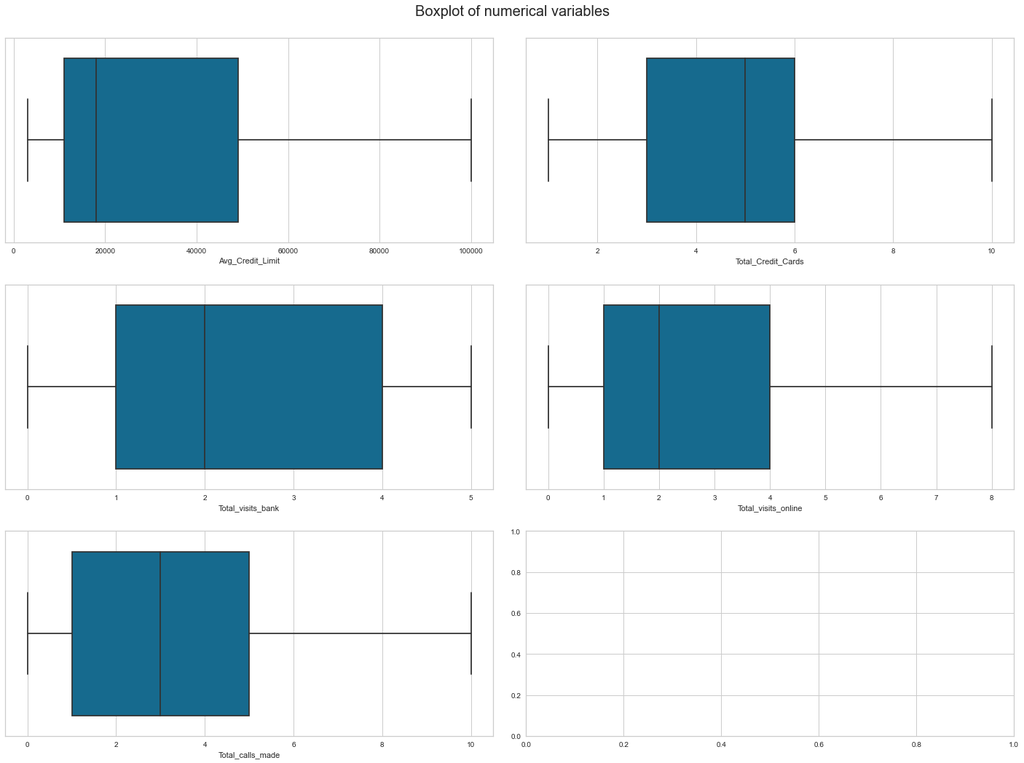

```python
# selecting numerical columns, in this case all the 5 existing columns
all_col = data1.select_dtypes(include=np.number).columns.tolist()
num_plots = len(all_col)
print(num_plots, 'plots')

fig, axes = plt.subplots(3, 2, figsize=(20, 15))
fig.suptitle('Boxplot of numerical variables', fontsize=20)
counter = 0
for ii in range(3):
    if counter < num_plots:
        sns.boxplot(ax=axes[ii][0],x=data1[all_col[counter]])
        counter = counter+1
    if counter < num_plots:
        sns.boxplot(ax=axes[ii][1],x=data1[all_col[counter]])
        counter = counter+1
    else:
        pass

fig.tight_layout(pad=2.0)
```

```
5 plots
```

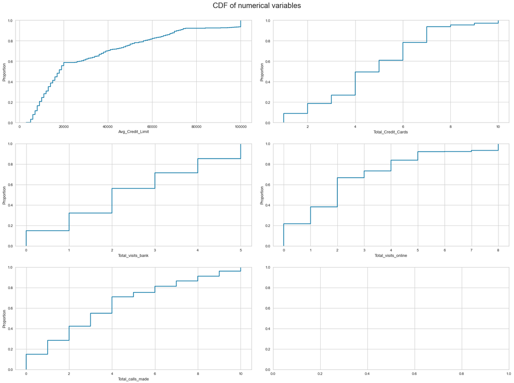

```python
# selecting numerical columns, in this case all the 5 existing columns
all_col = data1.select_dtypes(include=np.number).columns.tolist()
num_plots = len(all_col)
print(num_plots, 'plots')

fig, axes = plt.subplots(3, 2, figsize=(20, 15))
fig.suptitle('CDF of numerical variables', fontsize=20)
counter = 0
for ii in range(3):
    if counter < num_plots:
        sns.ecdfplot(ax=axes[ii][0],x=data1[all_col[counter]])
        counter = counter+1
    if counter < num_plots:
        sns.ecdfplot(ax=axes[ii][1],x=data1[all_col[counter]])
        counter = counter+1
    else:
        pass

fig.tight_layout(pad=2.0)
```

### Bivariate analysis

```python
# Recalling the dataset
data1.info()
```

```
<class 'pandas.core.frame.DataFrame'>
Int64Index: 649 entries, 0 to 659
Data columns (total 5 columns):
 #   Column               Non-Null Count  Dtype
---  ------               --------------  -----
 0   Avg_Credit_Limit     649 non-null    int64
 1   Total_Credit_Cards   649 non-null    int64
 2   Total_visits_bank    649 non-null    int64
 3   Total_visits_online  649 non-null    int64
 4   Total_calls_made     649 non-null    int64
dtypes: int64(5)
memory usage: 30.4 KB
```

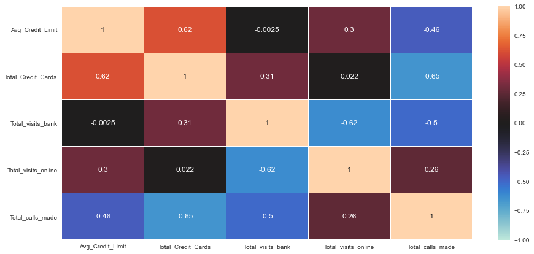

```python
plt.figure(figsize=(15,7))

sns.heatmap(data1[all_col].corr(),
            annot=True,
            linewidths=0.5,vmin=-1,vmax=1,
            center=0,
            cbar=True,)

plt.show()
```

**Observations**

- Avg_Credit_Limit is highly positively correlated with Total_Credit_Cards and negatively with Total_calls_made.
- Total_Credit_Cards is also highly negatively correlated with Total_calls_made.
- Total_visits_bank is highly negatively correlated with Total_visits_online.
- Total_calls_made is also negatively correlated with Total_visits_bank.

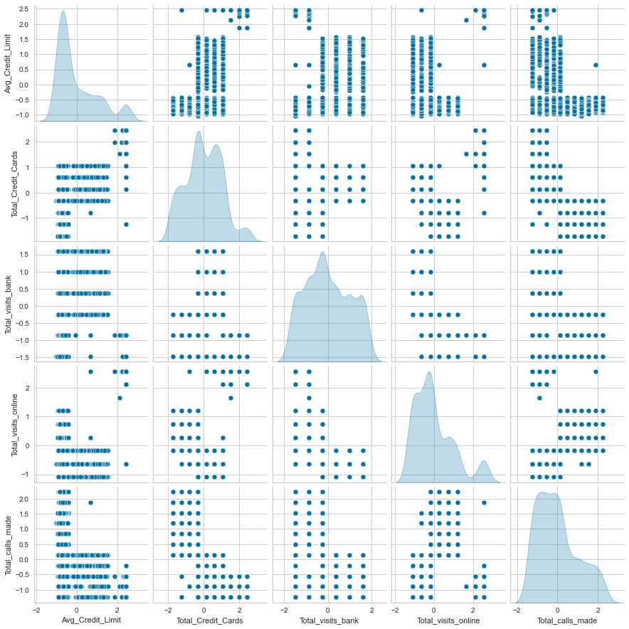

```python
# Scaling with zscore and pairplotting the dataset before clustering
data2=data1.iloc[:,:]
data2_Scaled=data2.apply(zscore)
sns.pairplot(data2_Scaled,diag_kind='kde')
```

**Key meaningful observations based on the EDA**

- There are strong correlations between several of the variables.
- The pairplots seem to disclose the existence of 3 or 4 clear clusters.
- We pass to analyze the clustering with K-means.

## Kmeans

- Apply K-means - Elbow curve - Silhouette Score - figure out appropriate number of cluster

```python
data3=data2_Scaled
data3.head()
```

|  | Avg_Credit_Limit | Total_Credit_Cards | Total_visits_bank | Total_visits_online | Total_calls_made |
| --- | --- | --- | --- | --- | --- |
| 0 | 2.457089 | -1.247087 | -0.860606 | -0.631528 | -1.248443 |
| 1 | 0.660421 | -0.786701 | -1.476410 | 2.563384 | 1.881237 |
| 2 | 0.660421 | 1.054846 | -0.860606 | 0.281304 | 0.142526 |
| 3 | -0.058246 | 0.134072 | -0.860606 | -0.631528 | 0.142526 |
| 4 | 2.457089 | 0.594459 | -1.476410 | 2.563384 | -0.205216 |

```
Number of Clusters: 1 	Average Distortion: 2.0813781667009046
Number of Clusters: 2 	Average Distortion: 1.5021902989274596
Number of Clusters: 3 	Average Distortion: 1.1875439378118793
Number of Clusters: 4 	Average Distortion: 1.074162412863776
Number of Clusters: 5 	Average Distortion: 1.007679464202981
Number of Clusters: 6 	Average Distortion: 0.9550666544337195
Number of Clusters: 7 	Average Distortion: 0.9181245688277537
Number of Clusters: 8 	Average Distortion: 0.8934135285682053
Number of Clusters: 9 	Average Distortion: 0.8750144396536167
Number of Clusters: 10 	Average Distortion: 0.8559786122787616
```

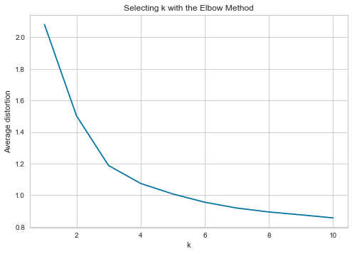

```python
clusters=range(1,11)
meanDistortions=[]

for k in clusters:
    model=KMeans(n_clusters=k)
    model.fit(data3)
    prediction=model.predict(data3)
    distortion=sum(np.min(cdist(data3, model.cluster_centers_, 'euclidean'), axis=1)) / data3.shape[0]
    meanDistortions.append(distortion)
    print('Number of Clusters:', k, '\tAverage Distortion:', distortion)

plt.plot(clusters, meanDistortions, 'bx-')
plt.xlabel('k')
plt.ylabel('Average distortion')
plt.title('Selecting k with the Elbow Method')
```

**Appropriate k seems to be 3 or 4.**

```
For n_clusters = 2, silhouette score is 0.42068161227301104)
For n_clusters = 3, silhouette score is 0.5168255536321152)
For n_clusters = 4, silhouette score is 0.3838879493461844)
For n_clusters = 5, silhouette score is 0.3559159856638849)
For n_clusters = 6, silhouette score is 0.2730912316469251)
For n_clusters = 7, silhouette score is 0.26726939135231054)
For n_clusters = 8, silhouette score is 0.2558159123351451)
For n_clusters = 9, silhouette score is 0.2579519007454559)
For n_clusters = 10, silhouette score is 0.24539939278983228)
```

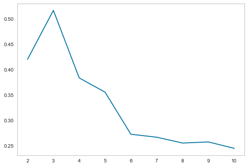

```python
# Analysis with Silhoutte clustering
sil_score = []
cluster_list = list(range(2,11))
for n_clusters in cluster_list:
    clusterer = KMeans(n_clusters=n_clusters)
    preds = clusterer.fit_predict((data3))
    #centers = clusterer.cluster_centers_
    score = silhouette_score(data3, preds)
    sil_score.append(score)
    print("For n_clusters = {}, silhouette score is {})".format(n_clusters, score))

plt.plot(cluster_list,sil_score)
plt.grid()
```

**Silhouette score for 3 is high, so we will choose 3 as value of k, as it is also confirmed in the next plots**

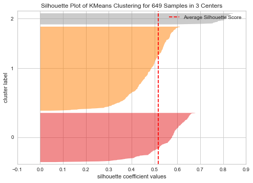

```python
# Finding optimal no. of clusters with silhouette coefficients (here n=3)
visualizer = SilhouetteVisualizer(KMeans(3, random_state = 1))
visualizer.fit(data3)
visualizer.show();
```

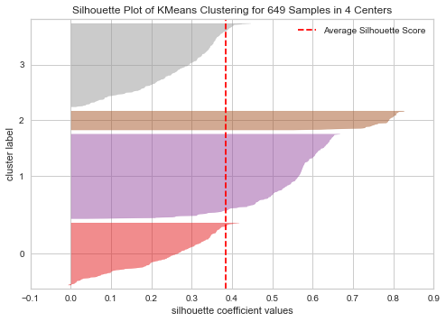

```python
# Finding optimal no. of clusters with silhouette coefficients (here n=4)
visualizer = SilhouetteVisualizer(KMeans(4, random_state = 1))
visualizer.fit(data3)
visualizer.show();
```

```python
# Let us group with K = 3
kmeans=KMeans(n_clusters=3, random_state=0)
kmeans.fit(data3)
prediction=kmeans.predict(data3)

#Append the prediction
data2["GROUP"] = prediction
data3["GROUP"] = prediction
```

```python
print("Groups Assigned : \n")
#data3.head()
data2.head(10)
```

```
Groups Assigned :
```

|  | Avg_Credit_Limit | Total_Credit_Cards | Total_visits_bank | Total_visits_online | Total_calls_made | GROUP |
| --- | --- | --- | --- | --- | --- | --- |
| 0 | 100000 | 2 | 1 | 1 | 0 | 1 |
| 1 | 50000 | 3 | 0 | 8 | 9 | 0 |
| 2 | 50000 | 7 | 1 | 3 | 4 | 1 |
| 3 | 30000 | 5 | 1 | 1 | 4 | 1 |
| 4 | 100000 | 6 | 0 | 8 | 3 | 2 |
| 5 | 20000 | 3 | 0 | 1 | 8 | 0 |
| 6 | 100000 | 5 | 0 | 8 | 2 | 2 |
| 7 | 15000 | 3 | 0 | 1 | 1 | 0 |
| 8 | 5000 | 2 | 0 | 2 | 2 | 0 |
| 9 | 3000 | 4 | 0 | 1 | 7 | 0 |

### Analyze the distribution of the data among the groups (K = 3) with boxplot

```python
data2Clust = data2.groupby(['GROUP']).mean()
data2Clust.head()
```

| GROUP | Avg_Credit_Limit | Total_Credit_Cards | Total_visits_bank | Total_visits_online | Total_calls_made |
| --- | --- | --- | --- | --- | --- |
| 0 | 12239.819005 | 2.411765 | 0.945701 | 3.552036 | 6.891403 |
| 1 | 34071.428571 | 5.518519 | 3.484127 | 0.981481 | 1.992063 |
| 2 | 98760.000000 | 8.740000 | 0.600000 | 7.820000 | 1.080000 |

```python
# lets display cluster profile
data2Clust['count_in_each_cluster'] = data2.groupby('GROUP')['Total_Credit_Cards'].count().values
data2Clust.style.highlight_max(color = 'lightgreen', axis = 0)
```

| GROUP | Avg_Credit_Limit | Total_Credit_Cards | Total_visits_bank | Total_visits_online | Total_calls_made | count_in_each_cluster |
| --- | --- | --- | --- | --- | --- | --- |
| 0 | 12239.819005 | 2.411765 | 0.945701 | 3.552036 | 6.891403 | 221 |
| 1 | 34071.428571 | 5.518519 | 3.484127 | 0.981481 | 1.992063 | 378 |
| 2 | 98760.000000 | 8.740000 | 0.600000 | 7.820000 | 1.080000 | 50 |

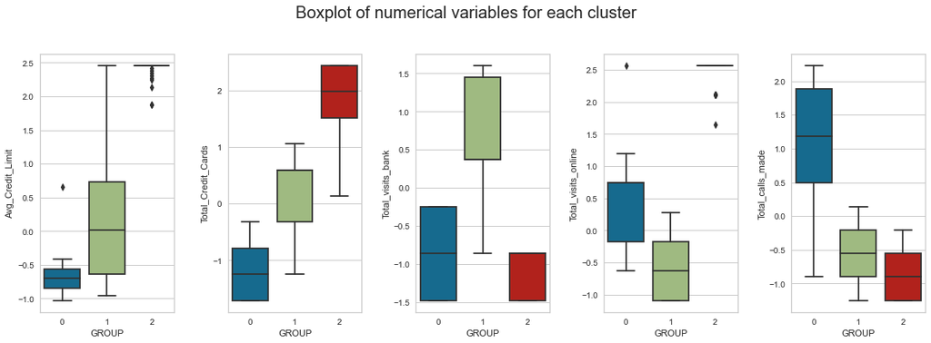

```python
fig, axes = plt.subplots(1, 5,  figsize=(16, 6))
fig.suptitle('Boxplot of numerical variables for each cluster', fontsize=20)
counter = 0
for ii in range(5):
    sns.boxplot(ax=axes[ii],y=data3[all_col[counter]],x=data3['GROUP'])
    counter = counter+1

fig.tight_layout(pad=2.0)
```

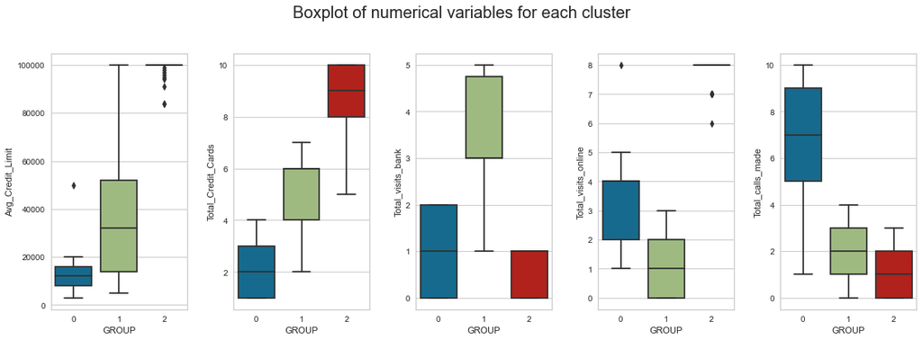

```python
fig, axes = plt.subplots(1, 5,  figsize=(16, 6))
fig.suptitle('Boxplot of numerical variables for each cluster', fontsize=20)
counter = 0
for ii in range(5):
    sns.boxplot(ax=axes[ii],y=data2[all_col[counter]],x=data2['GROUP'])
    counter = counter+1

fig.tight_layout(pad=2.0)
```